# Deliverable 2 — Estatística Multivariada

Indicadores organizacionais de maturidade no uso de IA

DAMA Intelligence — Ana Luiza Proença, Gustavo Gomes, Kaique Lira e Ricardo Matteo

20/10/2026

# 1 Objetivo e ponto de partida

O Deliverable 1 montou uma tabela analítica por colaborador e testou duas hipóteses com correlações e boxplots:

- **H1, treinamento aumenta o uso de IA:** confirmada, com efeito fraco (r = 0,11).
- **H2, treinamento reduz incidentes de segurança:** não confirmada (r = −0,02).

A própria conclusão do D1 pedia “uma análise multivariada mais robusta, controlando por área, cargo e exposição às ferramentas de IA”. Este relatório faz essa análise em quatro etapas:

1. constrói **indicadores organizacionais** por departamento, a partir de sete bases do projeto;
2. aplica **técnicas multivariadas** para reduzir esses indicadores a poucas dimensões interpretáveis: adequação (KMO e Bartlett), análise de componentes principais, análise fatorial com rotação varimax e confiabilidade;
3. constrói um **índice de maturidade em IA** e agrupa os departamentos por perfil, com clusters hierárquicos e k-means validados por MANOVA e análise discriminante;
4. **revisita H1 e H2** com regressão múltipla e regressão logística, agora com variáveis de controle.

# 2 Dados e unidade de análise

A unidade de análise é o **departamento**, porque é nele que a empresa decide licenças, treinamentos e orçamento. Por isso os indicadores do relatório são “organizacionais”. Os critérios de inclusão são:

- **Período:** janeiro a julho de 2026.
- **Colaboradores:** só os ativos.
- **Departamentos:** só os com pelo menos 5 colaboradores ativos, para que as proporções não oscilem por causa de uma ou duas pessoas.

```r
emp  <- ler("employees");  dep <- ler("departments"); comp <- ler("companies")
tr   <- ler("training_records"); lic <- ler("ai_licenses"); sec <- ler("security_events")
bil  <- ler("ai_billing");  bud <- ler("ai_budgets")
uso  <- ler("ai_usage_logs")[, c("timestamp", "employee_id", "ai_tool_id", "request_count",
                                 "input_tokens", "output_tokens", "request_status")]
uso$mes <- substr(uso$timestamp, 1, 7)
uso <- uso[uso$mes %in% MESES, ]
ok  <- uso[uso$request_status == "success", ]
ativos <- emp[emp$active %in% c("True", TRUE), ]
data.frame(base = c("employees (ativos)", "ai_usage_logs (jan–jul/2026)", "training_records", "ai_licenses",
                    "security_events", "ai_billing", "ai_budgets"),
           linhas = c(nrow(ativos), nrow(uso), nrow(tr), nrow(lic), nrow(sec), nrow(bil), nrow(bud)))
```

| base | linhas |
| --- | --- |
| employees (ativos) | 2158 |
| ai_usage_logs (jan–jul/2026) | 177803 |
| training_records | 1597 |
| ai_licenses | 5605 |
| security_events | 69 |
| ai_billing | 7025 |
| ai_budgets | 2254 |

## 2.1 Dicionário dos indicadores

| Indicador | Definição | Fonte | Dimensão esperada |
| --- | --- | --- | --- |
| `adocao` | % dos colaboradores ativos com ao menos uma requisição bem-sucedida | `ai_usage_logs` | Uso |
| `intensidade` | log(1 + requisições bem-sucedidas por colaborador por mês) | `ai_usage_logs` | Uso |
| `regularidade` | fração média dos 7 meses em que cada usuário usou IA | `ai_usage_logs` | Uso |
| `amplitude` | número médio de ferramentas diferentes por usuário | `ai_usage_logs` | Uso |
| `sucesso` | % das requisições concluídas com sucesso | `ai_usage_logs` | Qualidade técnica |
| `tokens_req` | log(tokens por requisição): quanto menor, mais enxuta a interação | `ai_usage_logs` | Eficiência |
| `capacitacao` | % dos colaboradores com ao menos um curso de IA concluído | `training_records` | Capacitação |
| `horas` | horas de curso concluídas por colaborador | `training_records` | Capacitação |
| `nota` | nota média nos cursos concluídos | `training_records` | Capacitação |
| `licencas` | licenças ativas por colaborador | `ai_licenses` | Investimento |
| `ociosas` | % das licenças ativas sem nenhum uso no período | `ai_licenses` × `ai_usage_logs` | Uso (sentido inverso) |
| `custo_colab` | log(gasto mensal com IA por colaborador, em R$) | `ai_billing` | Investimento |
| `execucao` | gasto mensal ÷ orçamento mensal do centro de custo | `ai_billing`, `ai_budgets` | Investimento |
| `incidentes` | eventos de segurança por 100 colaboradores | `security_events` | Risco |

# 3 Construção dos indicadores organizacionais

```r
por_colab <- ok %>% group_by(employee_id) %>%
  summarise(req = sum(request_count), tok = sum(input_tokens + output_tokens),
            meses = n_distinct(mes), ferr = n_distinct(ai_tool_id), .groups = "drop")
todas <- uso %>% group_by(employee_id) %>% summarise(req_total = sum(request_count), .groups = "drop")
cursos <- tr %>% filter(completion_status == "Concluido") %>% group_by(employee_id) %>%
  summarise(cursos = n(), nota = mean(score), horas = sum(duration_hours), .groups = "drop")
incid  <- sec %>% count(employee_id, name = "inc")
lic_at <- lic %>% filter(license_status == "Ativa") %>% count(employee_id, name = "lic")

colab <- ativos %>% left_join(por_colab, by = "employee_id") %>% left_join(todas, by = "employee_id") %>%
  left_join(cursos, by = "employee_id") %>% left_join(incid, by = "employee_id") %>%
  left_join(lic_at, by = "employee_id") %>%
  mutate(across(c(req, tok, meses, ferr, req_total, cursos, horas, inc, lic), ~ replace_na(.x, 0)))

usadas <- unique(paste(ok$employee_id, ok$ai_tool_id))
ociosidade <- lic %>% filter(license_status == "Ativa") %>%
  mutate(usada = paste(employee_id, ai_tool_id) %in% usadas) %>%
  inner_join(emp[, c("employee_id", "department_id")], by = "employee_id") %>%
  group_by(department_id) %>% summarise(ociosas = 1 - mean(usada), .groups = "drop")

bil$custo_brl <- ifelse(bil$currency == "USD", bil$total_cost * CAMBIO, bil$total_cost)
gasto <- bil %>% filter(billing_month %in% MESES) %>% group_by(cost_center) %>%
  summarise(gasto = sum(custo_brl) / length(MESES), .groups = "drop")
orcado <- bud %>% filter(year == 2026, month <= 7) %>% group_by(cost_center) %>%
  summarise(orcado = mean(budget_amount), .groups = "drop")

ind_todos <- colab %>% group_by(department_id) %>% summarise(
    n            = n(),
    adocao       = mean(req > 0),
    intensidade  = log1p(sum(req) / n() / length(MESES)),
    regularidade = ifelse(any(req > 0), mean(meses[req > 0]) / length(MESES), 0),
    amplitude    = ifelse(any(req > 0), mean(ferr[req > 0]), 0),
    sucesso      = ifelse(sum(req_total) > 0, sum(req) / sum(req_total), NA),
    tokens_req   = ifelse(sum(req) > 0, log(sum(tok) / sum(req)), NA),
    capacitacao  = mean(cursos > 0),
    horas        = mean(horas),
    nota         = mean(nota, na.rm = TRUE),
    licencas     = mean(lic),
    incidentes   = 100 * sum(inc) / n(), .groups = "drop") %>%
  mutate(cost_center = paste0("CC-", department_id)) %>%
  left_join(ociosidade, by = "department_id") %>% left_join(gasto, by = "cost_center") %>%
  left_join(orcado, by = "cost_center") %>%
  mutate(ociosas = replace_na(ociosas, 0), custo_colab = log(gasto / n), execucao = gasto / orcado) %>%
  left_join(dep, by = "department_id") %>%
  left_join(comp[, c("company_id", "company_name", "industry")], by = "company_id") %>%
  mutate(nan = is.nan(nota), nota = ifelse(nan, NA, nota)) %>% select(-nan)

VARS <- c("adocao", "intensidade", "regularidade", "amplitude", "sucesso", "tokens_req", "capacitacao",
          "horas", "nota", "licencas", "ociosas", "custo_colab", "execucao", "incidentes")
ind <- ind_todos %>% filter(n >= N_MIN)
sem_uso <- ind %>% filter(adocao == 0)
base <- ind %>% filter(adocao > 0) %>% as.data.frame()
write.csv(ind_todos, "resultados/indicadores_departamentos.csv", row.names = FALSE)
cat(nrow(ind_todos), "departamentos com colaboradores ativos;", nrow(ind), "com pelo menos", N_MIN,
    "colaboradores;", nrow(sem_uso), "sem nenhum uso de IA no período (tratados à parte);", nrow(base), "na análise.\n")
```

```
## 154 departamentos com colaboradores ativos; 110 com pelo menos 5 colaboradores; 4 sem nenhum uso de IA no período (tratados à parte); 106 na análise.
```

Quatro departamentos não tiveram nenhum uso de IA no período. Para eles, intensidade, amplitude e tokens por requisição não fazem sentido. Ficam fora da análise fatorial e entram no ranking final na faixa mais baixa.

## 3.1 Estatística descritiva

```r
desc <- describe(base[, VARS])[, c("n", "mean", "sd", "min", "median", "max", "skew")]
kable(round(desc, 3), caption = "Indicadores organizacionais — departamentos na análise")
```

Indicadores organizacionais — departamentos na análise

|  | n | mean | sd | min | median | max | skew |
| --- | --- | --- | --- | --- | --- | --- | --- |
| adocao | 106 | 0,521 | 0,260 | 0,059 | 0,513 | 1,000 | 0,040 |
| intensidade | 106 | 4,721 | 1,671 | 0,549 | 4,747 | 7,836 | -0,255 |
| regularidade | 106 | 0,933 | 0,095 | 0,571 | 0,968 | 1,000 | -2,045 |
| amplitude | 106 | 3,468 | 1,673 | 1,833 | 3,000 | 7,000 | 0,613 |
| sucesso | 106 | 0,952 | 0,020 | 0,831 | 0,953 | 1,000 | -2,104 |
| tokens_req | 106 | 7,133 | 0,445 | 5,968 | 7,229 | 7,586 | -1,663 |
| capacitacao | 106 | 0,349 | 0,173 | 0,000 | 0,333 | 0,857 | 0,212 |
| horas | 106 | 1,013 | 0,552 | 0,000 | 0,978 | 2,712 | 0,334 |
| nota | 102 | 76,510 | 6,178 | 57,000 | 76,206 | 98,000 | 0,200 |
| licencas | 106 | 1,643 | 0,447 | 0,636 | 1,753 | 3,100 | -0,072 |
| ociosas | 106 | 0,524 | 0,249 | 0,000 | 0,555 | 1,000 | -0,264 |
| custo_colab | 106 | 5,317 | 0,367 | 4,379 | 5,389 | 6,224 | -0,234 |
| execucao | 106 | 0,829 | 0,674 | 0,136 | 0,641 | 3,960 | 1,785 |
| incidentes | 106 | 4,110 | 7,270 | 0,000 | 0,000 | 33,333 | 2,110 |

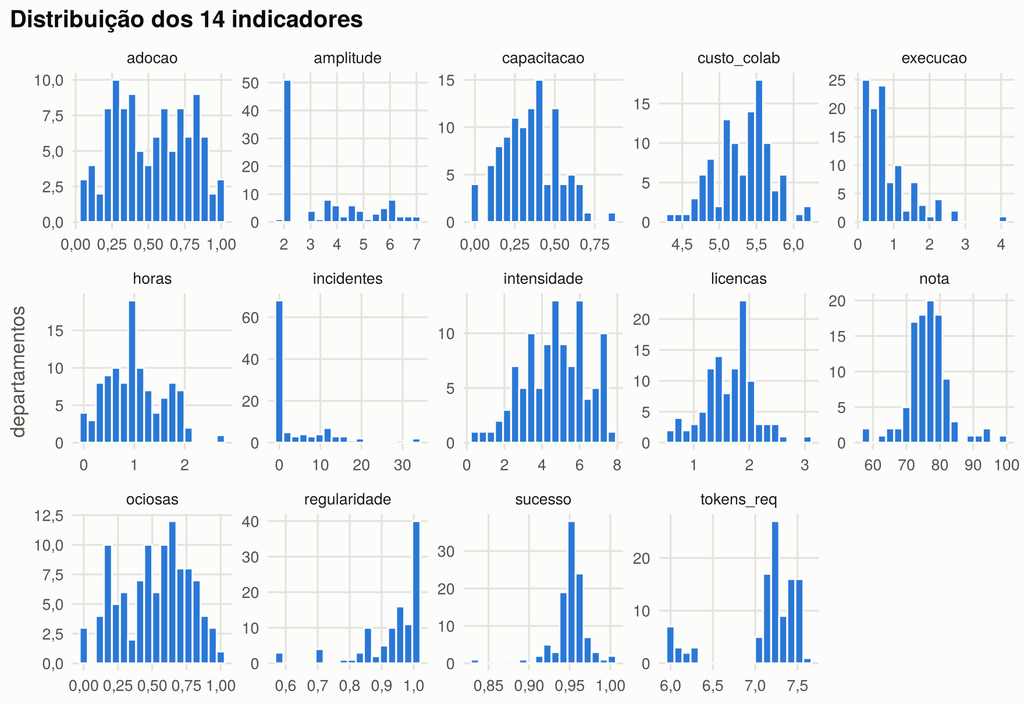

```r
longo <- base %>% select(all_of(VARS)) %>% pivot_longer(everything(), names_to = "indicador", values_to = "valor")
g <- ggplot(longo, aes(valor)) + geom_histogram(bins = 18, fill = AZUL, color = "#fcfcfb") +
  facet_wrap(~ indicador, scales = "free", ncol = 5) + labs(title = "Distribuição dos 14 indicadores", x = NULL, y = "departamentos")
salvar("fig01_distribuicoes.png", g, h = 5.5); g
```

# 4 Adequação dos dados à análise multivariada

## 4.1 Correlações

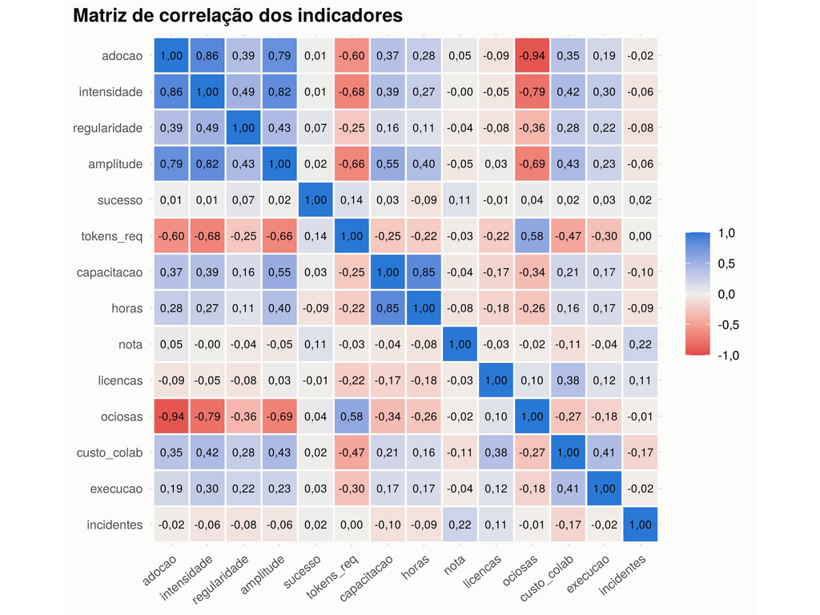

```r
R <- cor(base[, VARS], use = "pairwise.complete.obs")
cl <- as.data.frame(R) %>% mutate(v1 = rownames(R)) %>% pivot_longer(-v1, names_to = "v2", values_to = "r") %>%
  mutate(v1 = factor(v1, levels = VARS), v2 = factor(v2, levels = rev(VARS)))
g <- ggplot(cl, aes(v1, v2, fill = r)) + geom_tile(color = "#fcfcfb", linewidth = 0.6) +
  geom_text(aes(label = sub(".", ",", sprintf("%.2f", r), fixed = TRUE)), size = 2.8, color = TINTA) +
  scale_fill_gradient2(low = VERMELHO, mid = NEUTRO, high = AZUL, midpoint = 0, limits = c(-1, 1), name = "r") +
  labs(title = "Matriz de correlação dos indicadores", x = NULL, y = NULL) +
  theme(axis.text.x = element_text(angle = 40, hjust = 1), panel.grid = element_blank(), legend.position = "right") + coord_fixed()
salvar("fig02_correlacao.png", g, w = 8, h = 6.5); g
```

## 4.2 Observações atípicas multivariadas

A distância de Mahalanobis mede o quanto cada departamento se afasta do centro, considerando todas as variáveis ao mesmo tempo. Valores acima do quantil 0,999 da qui-quadrado são marcados como atípicos.

```r
cand <- setdiff(VARS, "nota")                 # nota tem ausências; entra só se passar na triagem
Xc <- base[complete.cases(base[, cand]), ]
Zc <- scale(Xc[, cand])
d2 <- mahalanobis(Zc, colMeans(Zc), cov(Zc))
lim <- qchisq(0.999, df = length(cand))
atip <- Xc[d2 > lim, c("department_id", "department_name", "company_name", "n")]
atip$D2 <- round(d2[d2 > lim], 1)
atip
```

|  | department_id | department_name | company_name | n | D2 |
| --- | --- | --- | --- | --- | --- |
| 45 | C07-D07 | RH | Capital Sul Investimentos | 6 | 37,3 |
| 77 | C13-D02 | Logistica e Supply Chain | Lojas Formosa | 5 | 39,8 |
| 99 | C16-D07 | Consultoria e Projetos | ServPro Facilities | 8 | 53,0 |

Os departamentos marcados são poucos e são casos reais da base, não erros de cadastro. Por isso permanecem na análise. A extração por máxima verossimilhança, usada adiante, é sensível a eles. Por isso a seção 7 refaz a análise fatorial sem os atípicos e compara as cargas.

## 4.3 KMO, MSA e teste de Bartlett

O KMO compara correlações simples com correlações parciais. Valores acima de 0,7 indicam que os dados têm estrutura comum suficiente para a análise fatorial. O MSA é o mesmo critério calculado por variável. A triagem remove, uma de cada vez, a variável de menor MSA enquanto ela estiver abaixo de 0,5.

```r
vars <- cand
removidas <- data.frame()
repeat {
  k <- KMO(Xc[, vars])
  if (min(k$MSAi) >= 0.5) break
  pior <- names(which.min(k$MSAi))
  removidas <- rbind(removidas, data.frame(variavel = pior, MSA = round(min(k$MSAi), 3), KMO_antes = round(k$MSA, 3)))
  vars <- setdiff(vars, pior)
}
k <- KMO(Xc[, vars])
removidas
```

| variavel | MSA | KMO_antes |
| --- | --- | --- |
| sucesso | 0,221 | 0,760 |
| incidentes | 0,440 | 0,765 |

```r
data.frame(variavel = names(k$MSAi), MSA = round(k$MSAi, 3), row.names = NULL)
```

| variavel | MSA |
| --- | --- |
| adocao | 0,734 |
| intensidade | 0,878 |
| regularidade | 0,807 |
| amplitude | 0,847 |
| tokens_req | 0,828 |
| capacitacao | 0,644 |
| horas | 0,634 |
| licencas | 0,526 |
| ociosas | 0,755 |
| custo_colab | 0,782 |
| execucao | 0,805 |

```r
bart <- cortest.bartlett(cor(Xc[, vars]), n = nrow(Xc))
cn <- base[complete.cases(base[, c(cand, "nota")]), c(cand, "nota")]
msa_nota <- KMO(cn)$MSAi["nota"]
cat(spf("KMO global = %.3f | Bartlett: qui² = %.1f, gl = %d, p = %.2e | n = %d departamentos, %d variáveis\n",
            k$MSA, bart$chisq, bart$df, bart$p.value, nrow(Xc), length(vars)))
```

```
## KMO global = 0,770 | Bartlett: qui² = 850,0, gl = 55, p = 6,15e-143 | n = 106 departamentos, 11 variáveis
```

`nota` ficou fora da triagem por dois motivos: tem ausências (departamentos sem nenhum curso concluído) e, calculado nos 102 departamentos sem ausência, seu MSA é 0,35, abaixo de 0,5. A triagem removeu ainda sucesso e incidentes, porque quase não se correlacionam com os demais indicadores. Na base, quase toda requisição tem sucesso e incidentes são raros. Os incidentes voltam na seção 10, como desfecho.

# 5 Análise de componentes principais

```r
Z <- scale(Xc[, vars])
pca <- prcomp(Z)
autov <- data.frame(componente = paste0("CP", seq_along(pca$sdev)), autovalor = round(pca$sdev^2, 3),
                    variancia = round(pca$sdev^2 / sum(pca$sdev^2), 3)) %>% mutate(acumulada = cumsum(variancia))
set.seed(42)
pa <- fa.parallel(Z, fa = "both", plot = FALSE, n.iter = 50)
```

```
## Parallel analysis suggests that the number of factors =  3  and the number of components =  3
```

```r
autov$aleatorio_paralela <- round(pa$pc.sim[seq_len(nrow(autov))], 3)
autov
```

| componente | autovalor | variancia | acumulada | aleatorio_paralela |
| --- | --- | --- | --- | --- |
| CP1 | 4,982 | 0,453 | 0,453 | 1,537 |
| CP2 | 1,688 | 0,153 | 0,606 | 1,383 |
| CP3 | 1,342 | 0,122 | 0,728 | 1,264 |
| CP4 | 0,918 | 0,083 | 0,811 | 1,155 |
| CP5 | 0,688 | 0,063 | 0,874 | 1,065 |
| CP6 | 0,430 | 0,039 | 0,913 | 0,972 |
| CP7 | 0,388 | 0,035 | 0,948 | 0,885 |
| CP8 | 0,265 | 0,024 | 0,972 | 0,810 |
| CP9 | 0,137 | 0,012 | 0,984 | 0,729 |
| CP10 | 0,123 | 0,011 | 0,995 | 0,646 |
| CP11 | 0,040 | 0,004 | 0,999 | 0,553 |

```r
cat("Critério de Kaiser (autovalor > 1):", sum(autov$autovalor > 1), "componentes | análise paralela:",
    pa$ncomp, "componentes e", pa$nfact, "fatores\n")
```

```
## Critério de Kaiser (autovalor > 1): 3 componentes | análise paralela: 3 componentes e 3 fatores
```

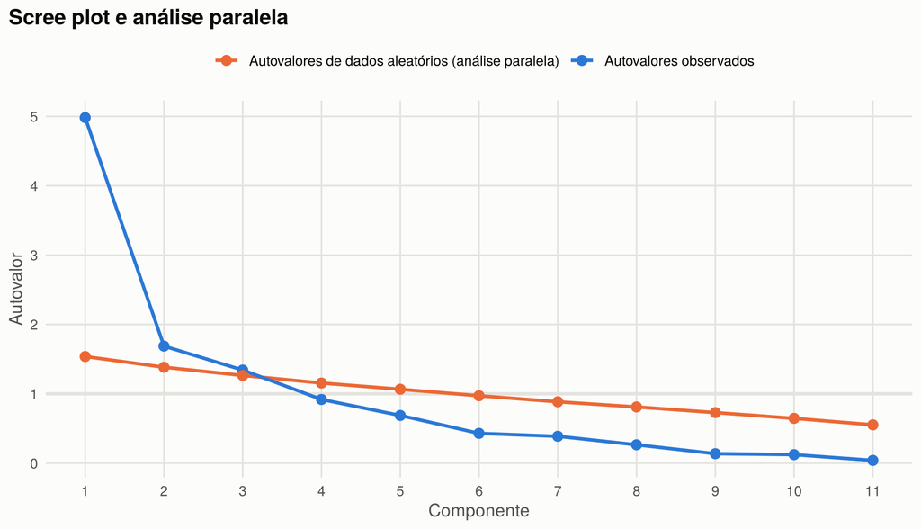

```r
sc_df <- data.frame(k = seq_along(pca$sdev), observado = pca$sdev^2, aleatorio = pa$pc.sim[seq_along(pca$sdev)]) %>%
  pivot_longer(-k, names_to = "serie", values_to = "autovalor")
g <- ggplot(sc_df, aes(k, autovalor, color = serie)) + geom_hline(yintercept = 1, color = GRADE, linewidth = 1) +
  geom_line(linewidth = 1) + geom_point(size = 2.6) +
  scale_color_manual(values = c(observado = AZUL, aleatorio = LARANJA),
                     labels = c(observado = "Autovalores observados", aleatorio = "Autovalores de dados aleatórios (análise paralela)")) +
  scale_x_continuous(breaks = seq_along(pca$sdev)) + labs(title = "Scree plot e análise paralela", x = "Componente", y = "Autovalor")
salvar("fig03_scree.png", g); g
```

```r
kable(round(pca$rotation[, 1:3], 3), caption = "Cargas dos três primeiros componentes (autovetores)")
```

Cargas dos três primeiros componentes (autovetores)

|  | PC1 | PC2 | PC3 |
| --- | --- | --- | --- |
| adocao | -0,399 | 0,003 | -0,286 |
| intensidade | -0,408 | -0,054 | -0,193 |
| regularidade | -0,231 | -0,072 | -0,170 |
| amplitude | -0,403 | 0,018 | -0,026 |
| tokens_req | 0,336 | 0,233 | -0,026 |
| capacitacao | -0,260 | 0,466 | 0,392 |
| horas | -0,217 | 0,491 | 0,445 |
| licencas | 0,000 | -0,544 | 0,359 |
| ociosas | 0,376 | -0,020 | 0,315 |
| custo_colab | -0,243 | -0,369 | 0,366 |
| execucao | -0,173 | -0,214 | 0,370 |

Os três critérios indicam três dimensões: Kaiser, scree e análise paralela. Juntas, elas explicam 72,8% da variância total. A PCA resume a informação, mas não separa bem os construtos: o primeiro componente carrega quase todos os indicadores. Para interpretar as dimensões, a seção seguinte usa a análise fatorial com rotação.

# 6 Análise fatorial exploratória

Extração por **máxima verossimilhança**, com **3 fatores** (pela análise paralela) e rotação **varimax**. A rotação ortogonal foi escolhida porque os escores entram somados no índice, e fatores não correlacionados evitam contar a mesma informação duas vezes.

```r
af <- fa(Z, nfactors = 3, rotate = "varimax", fm = "ml", scores = "regression")
ordem <- order(colSums(af$loadings^2), decreasing = TRUE)
L <- unclass(af$loadings)[, ordem]
NOMES <- c("F1_uso", "F2_capacitacao", "F3_investimento")
colnames(L) <- NOMES
cargas <- data.frame(variavel = rownames(L), round(L, 3), comunalidade = round(af$communality, 3), row.names = NULL)
write.csv(cargas, "resultados/cargas_fatoriais.csv", row.names = FALSE)
kable(cargas, caption = "Cargas fatoriais (varimax) e comunalidades")
```

Cargas fatoriais (varimax) e comunalidades

| variavel | F1_uso | F2_capacitacao | F3_investimento | comunalidade |
| --- | --- | --- | --- | --- |
| adocao | 0,983 | 0,158 | 0,056 | 0,994 |
| intensidade | 0,828 | 0,196 | 0,322 | 0,828 |
| regularidade | 0,376 | 0,067 | 0,256 | 0,211 |
| amplitude | 0,722 | 0,379 | 0,375 | 0,806 |
| tokens_req | -0,569 | -0,104 | -0,523 | 0,608 |
| capacitacao | 0,215 | 0,972 | 0,058 | 0,995 |
| horas | 0,145 | 0,838 | 0,010 | 0,723 |
| licencas | -0,090 | -0,183 | 0,461 | 0,254 |
| ociosas | -0,932 | -0,140 | 0,015 | 0,888 |
| custo_colab | 0,304 | 0,116 | 0,575 | 0,437 |
| execucao | 0,157 | 0,113 | 0,393 | 0,192 |

```r
var_exp <- colSums(L^2) / length(vars)
cat(spf("Variância explicada: F1 %.1f%%, F2 %.1f%%, F3 %.1f%% (total %.1f%%)\n", 100 * var_exp[1], 100 * var_exp[2], 100 * var_exp[3], 100 * sum(var_exp)))
```

```
## Variância explicada: F1 33,6%, F2 17,7%, F3 11,7% (total 63,1%)
```

```r
cat(spf("Ajuste: TLI = %.3f | RMSEA = %.3f | qui² = %.1f (gl = %d)\n", af$TLI, af$RMSEA[1], af$STATISTIC, af$dof))
```

```
## Ajuste: TLI = 0,907 | RMSEA = 0,111 | qui² = 57,8 (gl = 25)
```

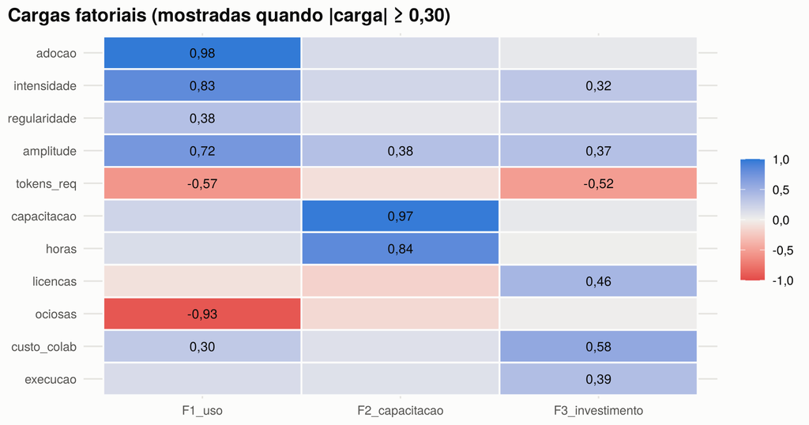

```r
cl2 <- as.data.frame(L) %>% mutate(variavel = factor(rownames(L), levels = rev(rownames(L)))) %>%
  pivot_longer(-variavel, names_to = "fator", values_to = "carga")
g <- ggplot(cl2, aes(fator, variavel, fill = carga)) + geom_tile(color = "#fcfcfb", linewidth = 0.6) +
  geom_text(aes(label = ifelse(abs(carga) >= 0.3, sub(".", ",", sprintf("%.2f", carga), fixed = TRUE), "")), size = 3.3, color = TINTA) +
  scale_fill_gradient2(low = VERMELHO, mid = NEUTRO, high = AZUL, midpoint = 0, limits = c(-1, 1), name = "carga") +
  labs(title = "Cargas fatoriais (mostradas quando |carga| ≥ 0,30)", x = NULL, y = NULL) +
  theme(panel.grid = element_blank(), legend.position = "right")
salvar("fig04_cargas.png", g, h = 4.2); g
```

## 6.1 Interpretação dos fatores

- **F1 — Uso efetivo de IA.** Cargas altas em adoção, intensidade, amplitude e regularidade, e cargas negativas em licenças ociosas e tokens por requisição. Departamentos com F1 alto usam IA de forma ampla e frequente e não deixam licenças paradas.
- **F2 — Capacitação.** Proporção de colaboradores com curso concluído e horas de curso por pessoa.
- **F3 — Investimento.** Gasto por colaborador, licenças por colaborador e execução do orçamento.

## 6.2 Confiabilidade (alfa de Cronbach)

```r
# itens em escalas diferentes (proporções, horas, reais): alfa padronizado, com os itens de sentido inverso invertidos
alfa <- function(cols, inverter = character()) {
  Zi <- scale(Xc[, cols]); Zi[, inverter] <- -Zi[, inverter]
  psych::alpha(as.data.frame(Zi), check.keys = FALSE, warnings = FALSE)$total$raw_alpha
}
conf <- data.frame(
  fator = NOMES,
  itens = c("adocao, intensidade, amplitude, regularidade, ociosas (−), tokens_req (−)", "capacitacao, horas", "custo_colab, licencas, execucao"),
  alfa_padronizado = round(c(alfa(c("adocao", "intensidade", "amplitude", "regularidade", "ociosas", "tokens_req"), c("ociosas", "tokens_req")),
                             alfa(c("capacitacao", "horas")), alfa(c("custo_colab", "licencas", "execucao"))), 3))
conf
```

| fator | itens | alfa_padronizado |
| --- | --- | --- |
| F1_uso | adocao, intensidade, amplitude, regularidade, ociosas (−), tokens_req (−) | 0,908 |
| F2_capacitacao | capacitacao, horas | 0,917 |
| F3_investimento | custo_colab, licencas, execucao | 0,563 |

Como os itens estão em escalas diferentes (proporções, horas, reais), o alfa é calculado sobre os itens padronizados, com os de sentido inverso (ociosas e tokens por requisição) invertidos. Uso (α = 0,908) e capacitação (α = 0,917) têm consistência interna alta, acima de 0,7. O de investimento (α = 0,563) fica abaixo de 0,6 e serve apenas para análise exploratória. Seus três itens medem facetas diferentes do gasto: quanto, quantas licenças e quanto do orçamento. Por isso ele é tratado como um índice à parte, e não como parte da maturidade.

## 6.3 Robustez: rotação oblíqua

```r
afo <- fa(Z, nfactors = 3, rotate = "oblimin", fm = "ml", scores = "regression")
kable(round(afo$Phi, 3), caption = "Correlação entre fatores com rotação oblimin")
```

Correlação entre fatores com rotação oblimin

|  | ML2 | ML1 | ML3 |
| --- | --- | --- | --- |
| ML2 | 1,000 | 0,386 | 0,465 |
| ML1 | 0,386 | 1,000 | 0,212 |
| ML3 | 0,465 | 0,212 | 1,000 |

Com rotação oblíqua, os fatores se correlacionam de forma moderada. Isso é esperado: quem usa mais também tende a capacitar e a investir mais. A seção 7 compara o índice calculado com as duas rotações.

# 7 Índices organizacionais

**Índice de Maturidade em IA (IMIA).** Combina uso efetivo (F1) e capacitação (F2), cada um com peso igual à sua parcela da variância explicada. O resultado é reescalado de 0 a 100. **Índice de Investimento (IINV).** É o escore de F3, também reescalado de 0 a 100. Os dois ficam separados porque maturidade é o que o departamento faz com a IA e investimento é quanto ele gasta para isso. A relação entre os dois mostra a eficiência.

```r
esc <- as.data.frame(af$scores[, ordem]); names(esc) <- NOMES
w <- var_exp[1:2] / sum(var_exp[1:2])
r01 <- function(x) 100 * (x - min(x)) / (max(x) - min(x))
dep_idx <- cbind(Xc[, c("department_id", "department_name", "company_id", "company_name", "industry", "n")], esc) %>%
  mutate(imia_bruto = w[1] * F1_uso + w[2] * F2_capacitacao, IMIA = r01(imia_bruto), IINV = r01(F3_investimento))
cat(spf("Pesos do IMIA: uso %.3f, capacitação %.3f\n", w[1], w[2]))
```

```
## Pesos do IMIA: uso 0,655, capacitação 0,345
```

```r
# robustez: o mesmo índice com escores oblimin
esc_o <- as.data.frame(afo$scores)
lo <- unclass(afo$loadings)
id_uso <- which.max(abs(lo["adocao", ])); id_cap <- which.max(abs(lo["capacitacao", ]))
imia_o <- w[1] * esc_o[, id_uso] * sign(lo["adocao", id_uso]) + w[2] * esc_o[, id_cap] * sign(lo["capacitacao", id_cap])
cat(spf("Correlação (Spearman) entre o IMIA com varimax e com oblimin: %.3f\n", cor(dep_idx$imia_bruto, imia_o, method = "spearman")))
```

```
## Correlação (Spearman) entre o IMIA com varimax e com oblimin: 0,995
```

```r
sem_md <- dep_idx$department_id %in% atip$department_id
af_sem <- fa(scale(Xc[!sem_md, vars]), nfactors = 3, rotate = "varimax", fm = "ml", scores = "regression")
cg <- factor.congruence(af$loadings[, ordem], af_sem$loadings)
cat(spf("Congruência de Tucker entre as cargas com e sem os %d atípicos: %s\n", sum(sem_md),
            paste(round(apply(abs(cg), 1, max), 3), collapse = ", ")))
```

```
## Congruência de Tucker entre as cargas com e sem os 3 atípicos: 1, 1, 1
```

```r
# departamentos sem uso entram no fim do ranking
dep_final <- bind_rows(dep_idx, sem_uso %>% transmute(department_id, department_name, company_id, company_name, industry, n, IMIA = 0)) %>%
  arrange(desc(IMIA))
write.csv(dep_final, "resultados/indices_departamentos.csv", row.names = FALSE)
```

```r
top <- dep_final %>% slice_head(n = 8) %>% transmute(departamento = department_name, empresa = company_name, setor = industry, n, IMIA = round(IMIA, 1), IINV = round(IINV, 1))
fim <- dep_final %>% slice_tail(n = 8) %>% transmute(departamento = department_name, empresa = company_name, setor = industry, n, IMIA = round(IMIA, 1), IINV = round(IINV, 1))
kable(top, caption = "Os 8 departamentos com maior maturidade")
```

Os 8 departamentos com maior maturidade

| departamento | empresa | setor | n | IMIA | IINV |
| --- | --- | --- | --- | --- | --- |
| Produto | Vortice Software | Tecnologia / Desenvolvimento de Software | 13 | 100,0 | 85,7 |
| Criacao | Ideia Fresca Marketing | Marketing | 18 | 97,3 | 0,8 |
| Marketing | Vortice Software | Tecnologia / Desenvolvimento de Software | 6 | 93,8 | 45,0 |
| Dados e Analytics | Vortice Software | Tecnologia / Desenvolvimento de Software | 13 | 91,6 | 79,6 |
| Produto | NexoCode Solucoes | Tecnologia / Desenvolvimento de Software | 18 | 91,3 | 68,1 |
| Vendas | NexoCode Solucoes | Tecnologia / Desenvolvimento de Software | 45 | 91,2 | 52,4 |
| Engenharia de Software | NexoCode Solucoes | Tecnologia / Desenvolvimento de Software | 102 | 90,4 | 83,5 |
| Marketing | MercadoPrime E-commerce | Varejo | 11 | 89,2 | 0,0 |

```r
kable(fim, caption = "Os 8 departamentos com menor maturidade (inclui os sem uso de IA, IMIA = 0)")
```

Os 8 departamentos com menor maturidade (inclui os sem uso de IA, IMIA = 0)

| departamento | empresa | setor | n | IMIA | IINV |
| --- | --- | --- | --- | --- | --- |
| Logistica | Quimica Bandeirantes | Industria | 14 | 5,7 | 55,5 |
| Comercial | Metalurgica Vale Forte | Industria | 35 | 4,8 | 67,2 |
| Financeiro | ServPro Facilities | Servicos | 5 | 4,2 | 61,2 |
| Compras | Metalurgica Vale Forte | Industria | 15 | 0,0 | 68,9 |
| Risco e Compliance | Capital Sul Investimentos | Financeiro | 6 | 0,0 | NA |
| Compras | Quimica Bandeirantes | Industria | 8 | 0,0 | NA |
| RH | Compra Certa Varejo | Varejo | 7 | 0,0 | NA |
| Comercial | ServPro Facilities | Servicos | 5 | 0,0 | NA |

```r
emp_idx <- dep_final %>% group_by(company_id, company_name, industry) %>%
  summarise(departamentos = n(), colaboradores = sum(n), IMIA = weighted.mean(IMIA, n),
            IINV = weighted.mean(IINV, n, na.rm = TRUE), .groups = "drop") %>% arrange(desc(IMIA))
write.csv(emp_idx, "resultados/indices_empresas.csv", row.names = FALSE)
kable(emp_idx %>% mutate(across(c(IMIA, IINV), ~ round(.x, 1))), caption = "Índices por empresa (média ponderada pelo número de colaboradores)")
```

Índices por empresa (média ponderada pelo número de colaboradores)

| company_id | company_name | industry | departamentos | colaboradores | IMIA | IINV |
| --- | --- | --- | --- | --- | --- | --- |
| C17 | Ideia Fresca Marketing | Marketing | 3 | 31 | 87,4 | 10,6 |
| C01 | NexoCode Solucoes | Tecnologia / Desenvolvimento de Software | 10 | 335 | 84,4 | 70,5 |
| C02 | Vortice Software | Tecnologia / Desenvolvimento de Software | 8 | 104 | 82,7 | 78,3 |
| C03 | Piloto Digital Sistemas | Tecnologia / Desenvolvimento de Software | 2 | 15 | 79,7 | 77,8 |
| C15 | Prisma Consultoria Empresarial | Servicos | 7 | 74 | 72,7 | 35,7 |
| C18 | Estrela Marketing Digital | Marketing | 4 | 58 | 72,3 | 40,3 |
| C04 | Cronos Tech Labs | Tecnologia / Desenvolvimento de Software | 10 | 95 | 70,9 | 63,6 |
| C14 | MercadoPrime E-commerce | Varejo | 8 | 114 | 61,9 | 34,5 |
| C05 | ByteFlow Engenharia de Software | Tecnologia / Desenvolvimento de Software | 2 | 11 | 55,3 | 74,2 |
| C06 | Banco Alterosa S.A. | Financeiro | 8 | 316 | 38,2 | 52,0 |
| C12 | Compra Certa Varejo | Varejo | 9 | 249 | 31,1 | 49,6 |
| C08 | Fincredi Solucoes Financeiras | Financeiro | 2 | 24 | 31,0 | 56,5 |
| C11 | TextilNorte Manufatura | Industria | 3 | 22 | 28,9 | 25,1 |
| C13 | Lojas Formosa | Varejo | 6 | 70 | 27,9 | 37,1 |
| C07 | Capital Sul Investimentos | Financeiro | 6 | 63 | 24,5 | 42,8 |
| C10 | Quimica Bandeirantes | Industria | 9 | 127 | 20,5 | 52,0 |
| C16 | ServPro Facilities | Servicos | 4 | 30 | 19,8 | 48,3 |
| C09 | Metalurgica Vale Forte | Industria | 9 | 306 | 17,2 | 56,9 |

```r
setor <- dep_final %>% group_by(industry) %>% summarise(departamentos = n(), IMIA = round(weighted.mean(IMIA, n), 1),
                                                        IINV = round(weighted.mean(IINV, n, na.rm = TRUE), 1), .groups = "drop") %>% arrange(desc(IMIA))
setor
```

| industry | departamentos | IMIA | IINV |
| --- | --- | --- | --- |
| Tecnologia / Desenvolvimento de Software | 32 | 81,1 | 71,1 |
| Marketing | 7 | 77,6 | 30,0 |
| Servicos | 11 | 57,4 | 38,9 |
| Varejo | 23 | 38,7 | 43,5 |
| Financeiro | 16 | 35,6 | 50,9 |
| Industria | 21 | 18,7 | 54,0 |

```r
mI <- median(dep_idx$IMIA); mV <- median(dep_idx$IINV)
dep_idx <- dep_idx %>% mutate(quadrante = case_when(
  IMIA >= mI & IINV <  mV ~ "Eficiente (maturidade alta, investimento baixo)",
  IMIA >= mI & IINV >= mV ~ "Avançado (maturidade alta, investimento alto)",
  IMIA <  mI & IINV >= mV ~ "Desperdício (maturidade baixa, investimento alto)",
  TRUE                    ~ "Inicial (maturidade baixa, investimento baixo)"))
qt <- dep_idx %>% count(quadrante, name = "departamentos")
qt
```

| quadrante | departamentos |
| --- | --- |
| Avançado (maturidade alta, investimento alto) | 26 |
| Desperdício (maturidade baixa, investimento alto) | 27 |
| Eficiente (maturidade alta, investimento baixo) | 27 |
| Inicial (maturidade baixa, investimento baixo) | 26 |

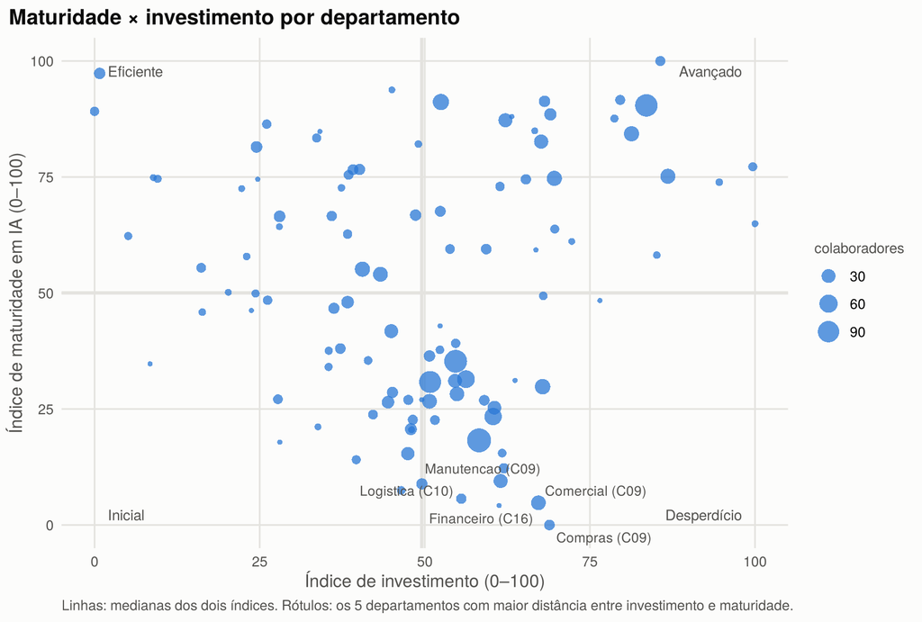

```r
rot <- dep_idx %>% filter(quadrante == "Desperdício (maturidade baixa, investimento alto)") %>% arrange(desc(IINV - IMIA)) %>% slice_head(n = 5)
g <- ggplot(dep_idx, aes(IINV, IMIA)) +
  geom_vline(xintercept = mV, color = GRADE, linewidth = 1) + geom_hline(yintercept = mI, color = GRADE, linewidth = 1) +
  geom_point(aes(size = n), color = AZUL, alpha = 0.75, stroke = 0) +
  geom_text_repel(data = rot, aes(label = paste0(department_name, " (", company_id, ")")), size = 3, color = TINTA2, seed = 1) +
  annotate("text", x = c(2, 98, 98, 2), y = c(99, 99, 1, 1), hjust = c(0, 1, 1, 0), vjust = c(1, 1, 0, 0), size = 3.2, color = TINTA2,
           label = c("Eficiente", "Avançado", "Desperdício", "Inicial")) +
  scale_size_continuous(range = c(1.5, 7), name = "colaboradores") +
  labs(title = "Maturidade × investimento por departamento", x = "Índice de investimento (0–100)", y = "Índice de maturidade em IA (0–100)",
       caption = "Linhas: medianas dos dois índices. Rótulos: os 5 departamentos com maior distância entre investimento e maturidade.") +
  theme(legend.position = "right", legend.title = element_text(color = TINTA2, size = 9), plot.caption = element_text(color = TINTA2, hjust = 0))
salvar("fig05_quadrantes.png", g, h = 5.4); g
```

# 8 Análise de agrupamentos

Os escores dos três fatores são agrupados de duas formas: por agrupamento hierárquico (método de Ward, distância euclidiana) e por k-means. O número de grupos é escolhido pela silhueta média.

```r
E <- as.matrix(esc)
dd <- dist(E)
hc <- hclust(dd, method = "ward.D2")
sil <- do.call(rbind, lapply(2:6, function(k) {
  set.seed(42); km <- kmeans(E, centers = k, nstart = 50)
  data.frame(k = k, silhueta_ward = mean(silhouette(cutree(hc, k), dd)[, 3]), silhueta_kmeans = mean(silhouette(km$cluster, dd)[, 3]))
}))
round(sil, 3)
```

| k | silhueta_ward | silhueta_kmeans |
| --- | --- | --- |
| 2 | 0,274 | 0,291 |
| 3 | 0,327 | 0,343 |
| 4 | 0,327 | 0,342 |
| 5 | 0,331 | 0,339 |
| 6 | 0,250 | 0,301 |

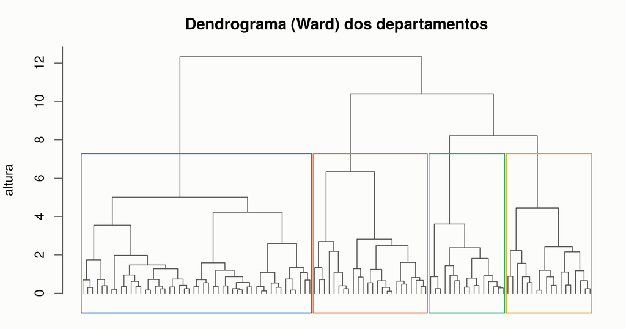

```r
K <- 4
op <- par(bg = "#fcfcfb", mar = c(1, 4, 3, 1))
plot(hc, labels = FALSE, hang = -1, main = "Dendrograma (Ward) dos departamentos", sub = "", xlab = "", ylab = "altura", col = TINTA2)
rect.hclust(hc, k = K, border = CORES_CLUSTER)
```

```r
par(op)
png("figuras/fig06_dendrograma.png", width = 1200, height = 630, res = 150, bg = "#fcfcfb")
plot(hc, labels = FALSE, hang = -1, main = "Dendrograma (Ward) dos departamentos", sub = "", xlab = "", ylab = "altura", col = TINTA2)
rect.hclust(hc, k = K, border = CORES_CLUSTER); invisible(dev.off())
```

A silhueta praticamente empata entre 3 e 4 grupos. A escolha foi **4 grupos**, porque o quarto separa dois perfis com ações diferentes: departamentos que usam IA sem capacitação, que representam risco de governança, e departamentos capacitados com investimento baixo. Com 3 grupos, esses dois perfis ficariam juntos. Os grupos finais saem do k-means.

```r
set.seed(42)
km <- kmeans(E, centers = K, nstart = 50)
dep_idx$cluster <- km$cluster
perfil <- dep_idx %>% bind_cols(Xc[, c("adocao", "capacitacao", "ociosas", "custo_colab", "execucao", "incidentes")]) %>%
  group_by(cluster) %>% summarise(departamentos = n(), colaboradores = sum(n),
                                  across(c(F1_uso, F2_capacitacao, F3_investimento, IMIA, IINV, adocao, capacitacao, ociosas, execucao, incidentes), mean), .groups = "drop")
# nomes a partir do perfil dos centróides
nomear <- function(p) {
  if (p$F1_uso > 0.5 && p$F3_investimento > 0.5) return("Avançados")
  if (p$F2_capacitacao > 0.5) return("Capacitados, investimento baixo")
  if (p$F1_uso > 0.5 && p$F2_capacitacao < 0) return("Uso sem capacitação")
  return("Adoção baixa")
}
perfil$perfil <- sapply(seq_len(nrow(perfil)), function(i) nomear(perfil[i, ]))
stopifnot(!anyDuplicated(perfil$perfil))   # cada grupo recebe um nome distinto
dep_idx$perfil <- perfil$perfil[match(dep_idx$cluster, perfil$cluster)]
write.csv(perfil, "resultados/perfil_clusters.csv", row.names = FALSE)
kable(perfil %>% select(perfil, everything(), -cluster) %>% mutate(across(where(is.numeric) & !c(departamentos, colaboradores), ~ round(.x, 2))),
      caption = "Perfil médio de cada grupo")
```

Perfil médio de cada grupo

| perfil | departamentos | colaboradores | F1_uso | F2_capacitacao | F3_investimento | IMIA | IINV | adocao | capacitacao | ociosas | execucao | incidentes |
| --- | --- | --- | --- | --- | --- | --- | --- | --- | --- | --- | --- | --- |
| Capacitados, investimento baixo | 26 | 389 | 0,21 | 1,04 | -0,55 | 69,36 | 35,53 | 0,61 | 0,53 | 0,44 | 0,79 | 4,57 |
| Adoção baixa | 43 | 1057 | -0,93 | -0,38 | 0,08 | 24,39 | 51,08 | 0,27 | 0,25 | 0,75 | 0,79 | 3,46 |
| Uso sem capacitação | 15 | 150 | 0,94 | -1,06 | -0,91 | 60,41 | 26,67 | 0,71 | 0,20 | 0,33 | 0,51 | 5,66 |
| Avançados | 22 | 422 | 0,94 | 0,24 | 1,11 | 76,92 | 76,56 | 0,79 | 0,43 | 0,31 | 1,16 | 3,77 |

```r
table(Perfil = dep_idx$perfil, Setor = dep_idx$industry)
```

```
##                                  Setor
## Perfil                            Financeiro Industria Marketing Servicos
##   Adoção baixa                            10        17         0        3
##   Avançados                                0         0         0        1
##   Capacitados, investimento baixo          2         1         5        6
##   Uso sem capacitação                      3         2         2        0
##                                  Setor
## Perfil                            Tecnologia / Desenvolvimento de Software
##   Adoção baixa                                                           2
##   Avançados                                                             21
##   Capacitados, investimento baixo                                        6
##   Uso sem capacitação                                                    3
##                                  Setor
## Perfil                            Varejo
##   Adoção baixa                        11
##   Avançados                            0
##   Capacitados, investimento baixo      6
##   Uso sem capacitação                  5
```

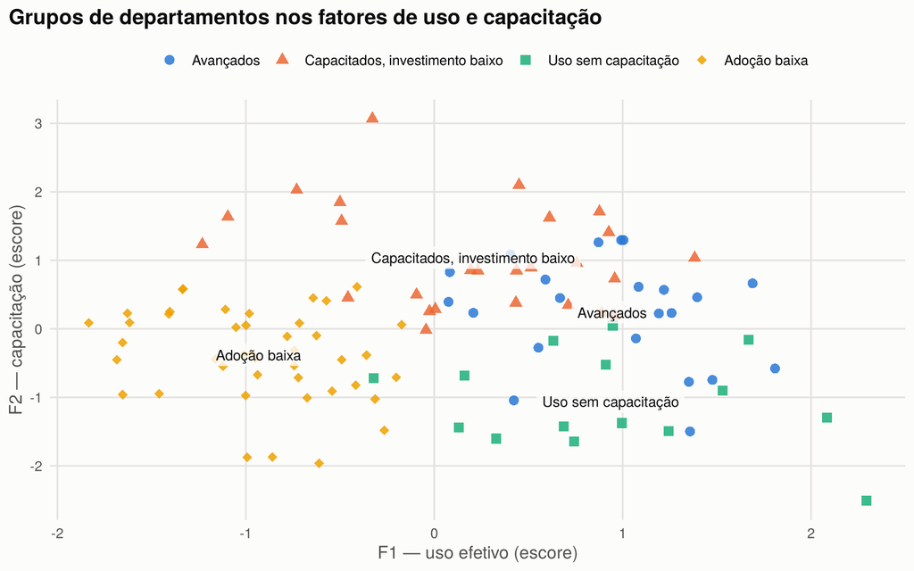

```r
ordem_p <- c("Avançados", "Capacitados, investimento baixo", "Uso sem capacitação", "Adoção baixa")
dep_idx$perfil <- factor(dep_idx$perfil, levels = ordem_p)
cent <- dep_idx %>% group_by(perfil) %>% summarise(F1_uso = mean(F1_uso), F2_capacitacao = mean(F2_capacitacao))
g <- ggplot(dep_idx, aes(F1_uso, F2_capacitacao, color = perfil, shape = perfil)) +
  geom_hline(yintercept = 0, color = GRADE) + geom_vline(xintercept = 0, color = GRADE) +
  geom_point(size = 2.6, alpha = 0.85) +
  geom_label(data = cent, aes(label = perfil), color = TINTA, fill = "#fcfcfbcc", size = 3.2, label.size = 0, show.legend = FALSE) +
  scale_color_manual(values = setNames(CORES_CLUSTER, ordem_p)) + scale_shape_manual(values = setNames(c(16, 17, 15, 18), ordem_p)) +
  labs(title = "Grupos de departamentos nos fatores de uso e capacitação", x = "F1 — uso efetivo (escore)", y = "F2 — capacitação (escore)")
salvar("fig07_clusters.png", g, h = 5); g
```

# 9 Validação dos grupos e diferenças entre setores

## 9.1 MANOVA

A MANOVA testa se os vetores de médias dos três fatores diferem entre os grupos e entre os setores. O teste usado é o traço de Pillai, o mais robusto a violações de pressupostos.

```r
m_cl <- manova(cbind(F1_uso, F2_capacitacao, F3_investimento) ~ perfil, data = dep_idx)
m_st <- manova(cbind(F1_uso, F2_capacitacao, F3_investimento) ~ industry, data = dep_idx)
summary(m_cl, test = "Pillai")
```

```
##            Df Pillai approx F num Df den Df              Pr(>F)
## perfil      3   1,81     51,4      9    306 <0,0000000000000002 ***
## Residuals 102
## ---
## Signif. codes:  0 '***' 0,001 '**' 0,01 '*' 0,05 '.' 0,1 ' ' 1
```

```r
summary(m_st, test = "Pillai")
```

```
##            Df Pillai approx F num Df den Df              Pr(>F)
## industry    5      1     10,1     15    300 <0,0000000000000002 ***
## Residuals 100
## ---
## Signif. codes:  0 '***' 0,001 '**' 0,01 '*' 0,05 '.' 0,1 ' ' 1
```

```r
summary.aov(m_st)
```

```
##  Response F1_uso :
##              Df Sum Sq Mean Sq F value             Pr(>F)
## industry      5   55,7   11,13    22,9 0,0000000000000028 ***
## Residuals   100   48,5    0,49
## ---
## Signif. codes:  0 '***' 0,001 '**' 0,01 '*' 0,05 '.' 0,1 ' ' 1
##
##  Response F2_capacitacao :
##              Df Sum Sq Mean Sq F value Pr(>F)
## industry      5   10,8   2,162    2,31  0,049 *
## Residuals   100   93,5   0,935
## ---
## Signif. codes:  0 '***' 0,001 '**' 0,01 '*' 0,05 '.' 0,1 ' ' 1
##
##  Response F3_investimento :
##              Df Sum Sq Mean Sq F value       Pr(>F)
## industry      5   28,9    5,78    12,2 0,0000000031 ***
## Residuals   100   47,5    0,47
## ---
## Signif. codes:  0 '***' 0,001 '**' 0,01 '*' 0,05 '.' 0,1 ' ' 1
```

## 9.2 Análise discriminante linear

A análise discriminante (LDA) com validação cruzada leave-one-out verifica se os grupos são separáveis por uma regra linear sobre os indicadores originais, e não apenas sobre os fatores que os criaram.

```r
d_lda <- cbind(as.data.frame(scale(Xc[, vars])), perfil = dep_idx$perfil)
lda_cv <- lda(perfil ~ ., data = d_lda, CV = TRUE)
conf_lda <- table(Real = d_lda$perfil, Previsto = lda_cv$class)
conf_lda
```

```
##                                  Previsto
## Real                              Avançados Capacitados, investimento baixo
##   Avançados                              18                               4
##   Capacitados, investimento baixo         1                              21
##   Uso sem capacitação                     0                               2
##   Adoção baixa                            2                               1
##                                  Previsto
## Real                              Uso sem capacitação Adoção baixa
##   Avançados                                         0            0
##   Capacitados, investimento baixo                   1            3
##   Uso sem capacitação                              10            3
##   Adoção baixa                                      0           40
```

```r
acerto <- mean(lda_cv$class == d_lda$perfil)
cat(spf("Acerto na validação cruzada: %.1f%% (acerto ao acaso pela maior classe: %.1f%%)\n",
            100 * acerto, 100 * max(table(d_lda$perfil)) / nrow(d_lda)))
```

```
## Acerto na validação cruzada: 84,0% (acerto ao acaso pela maior classe: 40,6%)
```

# 10 As hipóteses do D1, agora com controles

No nível do colaborador, as hipóteses do D1 são testadas de novo com as variáveis de controle que o próprio D1 sugeria:

- **setor** da empresa;
- **senioridade** (o cargo);
- **tempo de casa**;
- **licenças ativas**, como medida de exposição às ferramentas.

```r
colab_m <- colab %>% left_join(comp[, c("company_id", "industry")], by = "company_id") %>%
  mutate(log_req = log1p(req / length(MESES)), teve_incidente = as.integer(inc > 0),
         tempo_casa = as.numeric(as.Date("2026-07-31") - as.Date(hire_date)) / 365.25,
         seniority = factor(seniority, levels = c("Junior", "Pleno", "Senior", "Especialista", "Gerente")),
         industry = factor(industry))
h1_simples  <- lm(log_req ~ cursos, data = colab_m)
h1_controle <- lm(log_req ~ cursos + lic + seniority + tempo_casa + industry, data = colab_m)
h2_simples  <- glm(teve_incidente ~ cursos, family = binomial, data = colab_m)
h2_controle <- glm(teve_incidente ~ cursos + log_req + lic + seniority + tempo_casa + industry, family = binomial, data = colab_m)
coef_lin <- function(m, nome) { s <- summary(m)$coefficients["cursos", ]; data.frame(modelo = nome, coef = s[1], ep = s[2], p = s[4], R2 = summary(m)$r.squared) }
h1 <- rbind(coef_lin(h1_simples, "H1 sem controles"), coef_lin(h1_controle, "H1 com controles")); rownames(h1) <- NULL
kable(h1 %>% mutate(across(c(coef, ep, R2), ~ round(.x, 3)), p = signif(p, 3)),
      caption = "H1: efeito de cada curso concluído sobre log(1 + requisições/mês)")
```

H1: efeito de cada curso concluído sobre log(1 + requisições/mês)

| modelo | coef | ep | p | R2 |
| --- | --- | --- | --- | --- |
| H1 sem controles | 0,499 | 0,099 | 0,000 | 0,012 |
| H1 com controles | 0,055 | 0,083 | 0,505 | 0,333 |

```r
or <- function(m, nome) { b <- coef(summary(m))["cursos", ]; ci <- exp(b[1] + c(-1.96, 1.96) * b[2])
  data.frame(modelo = nome, OR = exp(b[1]), IC95_inf = ci[1], IC95_sup = ci[2], p = b[4]) }
h2 <- rbind(or(h2_simples, "H2 sem controles"), or(h2_controle, "H2 com controles")); rownames(h2) <- NULL
kable(h2 %>% mutate(across(c(OR, IC95_inf, IC95_sup), ~ round(.x, 3)), p = signif(p, 3)),
      caption = "H2: razão de chances de ter incidente por curso concluído")
```

H2: razão de chances de ter incidente por curso concluído

| modelo | OR | IC95_inf | IC95_sup | p |
| --- | --- | --- | --- | --- |
| H2 sem controles | 0,839 | 0,554 | 1,270 | 0,405 |
| H2 com controles | 0,820 | 0,537 | 1,251 | 0,357 |

```r
kable(round(summary(h1_controle)$coefficients, 3), caption = "Regressão múltipla completa (H1 com controles)")
```

Regressão múltipla completa (H1 com controles)

|  | Estimate | Std. Error | t value | Pr(>\|t\|) |
| --- | --- | --- | --- | --- |
| (Intercept) | 1,782 | 0,205 | 8,698 | 0,000 |
| cursos | 0,055 | 0,083 | 0,666 | 0,505 |
| lic | -0,215 | 0,069 | -3,124 | 0,002 |
| seniorityPleno | 0,146 | 0,133 | 1,100 | 0,271 |
| senioritySenior | 0,187 | 0,149 | 1,255 | 0,210 |
| seniorityEspecialista | 0,376 | 0,205 | 1,832 | 0,067 |
| seniorityGerente | 0,297 | 0,270 | 1,098 | 0,272 |
| tempo_casa | 0,008 | 0,032 | 0,264 | 0,792 |
| industryIndustria | -0,735 | 0,167 | -4,405 | 0,000 |
| industryMarketing | 2,474 | 0,270 | 9,171 | 0,000 |
| industryServicos | 0,846 | 0,261 | 3,236 | 0,001 |
| industryTecnologia / Desenvolvimento de Software | 3,500 | 0,157 | 22,261 | 0,000 |
| industryVarejo | -0,054 | 0,167 | -0,326 | 0,745 |

```r
cat(spf("N = %d colaboradores ativos; %d com algum incidente (%.1f%%)\n", nrow(colab_m), sum(colab_m$teve_incidente), 100 * mean(colab_m$teve_incidente)))
```

```
## N = 2158 colaboradores ativos; 64 com algum incidente (3,0%)
```

```r
ct <- cor.test(dep_idx$F2_capacitacao, Xc$incidentes, method = "spearman", exact = FALSE)
cat(spf("Nível departamento: correlação de Spearman entre capacitação (F2) e incidentes por 100 colaboradores = %.3f (p = %.3f)\n", ct$estimate, ct$p.value))
```

```
## Nível departamento: correlação de Spearman entre capacitação (F2) e incidentes por 100 colaboradores = -0,115 (p = 0,239)
```

# 11 Resultados e interpretação

1. **Os 14 indicadores se reduzem a três dimensões.** Do KMO de 0,77, com Bartlett significativo e 11 indicadores após a triagem, saem três fatores que explicam 63,1% da variância: **uso efetivo**, **capacitação** e **investimento**. O uso efetivo responde sozinho por 33,6%. Adoção e licenças ociosas são quase espelhos uma da outra: onde a adoção é baixa, a empresa paga licenças que ninguém usa.
2. **Incidentes e taxa de sucesso não acompanham as demais dimensões.** Eles saem na triagem do KMO. Do ponto de vista da gestão, isso significa que o risco de segurança não é explicado por quanto o departamento usa, treina ou gasta, e precisa de indicador próprio no painel.
3. **O IMIA ordena departamentos e empresas.** Tecnologia / Desenvolvimento de Software lidera e Industria fica por último, e a MANOVA confirma que o setor explica diferenças multivariadas nos três fatores. A diferença é forte no uso e no investimento e fraca na capacitação: o setor determina quanto se usa, mas não quanto se treina.
4. **27 departamentos estão no quadrante de desperdício**, com investimento acima da mediana e maturidade abaixo dela. São o primeiro alvo da realocação de licenças proposta no modelo de Pesquisa Operacional.
5. **Os quatro perfis são bem separados.** A MANOVA por grupo é significativa e a análise discriminante acerta 84% dos departamentos na validação cruzada. O grupo **uso sem capacitação** é o de maior risco de governança: usa IA tanto quanto os avançados, mas quase sem formação.
6. **H1 era confundida pelo setor.** Sem controles, cada curso concluído está associado a 0,499 a mais em log(1 + requisições/mês). Com setor, senioridade, tempo de casa e licenças, o efeito cai para 0,055 (p = 0,51), sem significância. A associação do D1 vinha do fato de que as empresas de tecnologia treinam mais e também usam mais. O curso em si não explica o uso.
7. **H2 continua não confirmada.** Com controles, a razão de chances de ter incidente por curso é 0,82 (p = 0,36), e o intervalo de confiança inclui 1. Também não há correlação entre capacitação e incidentes no nível do departamento.

## 11.1 O que isso muda no DAMA

- O painel organizacional do DAMA deve mostrar três indicadores-síntese: **uso efetivo, capacitação e investimento**. Os 11 indicadores ficam como detalhamento. O IMIA serve como indicador de maturidade por departamento e por empresa.
- O indicador de **licenças ociosas** é o sinal mais forte de baixa maturidade e o mais barato de corrigir. É ele que liga esta análise ao modelo de otimização de licenças.
- A hipótese de que treinamento por si só aumenta o uso e reduz incidentes não se sustenta nos dados. Os cursos precisam ser acompanhados de outras condições, como acesso às ferramentas certas e metas de uso, o que reforça a lógica de níveis de autonomia do produto.

## 11.2 Limitações

- A base é sintética. O orçamento foi gerado de forma independente do gasto, o que influencia o indicador de execução.
- Os incidentes são raros (64 colaboradores com incidente), o que limita o poder dos testes de H2.
- Os indicadores são médias do período, sem dimensão temporal. Uma análise longitudinal poderia testar se a capacitação precede o aumento de uso.
- O fator de investimento tem confiabilidade baixa (α = 0,563) e deve ser lido como exploratório.

```
## R4.3.3 | psych 2.4.1 | cluster 2.1.6 | MASS 7.3.60.0.1
```